# Lab04

Xiaoya Li

September 21, 2017

### Creating data frames

```r
#creating vectors for each of the columns
player <- c("Thompson", "Curry", "Green", "Durant", "Pachulia")
position <- c("SG", "PG", "PF", "SF", "C")
salary <- c(16663575, 12112359, 15330435, 26540100, 2898000)
points <- c(1742, 1999, 776, 1555, 426)
ppg <- c(22.3, 25.3, 10.2, 25.1, 6.1)
rookie <- c(FALSE,FALSE,FALSE,FALSE,FALSE)
```

```r
#create a first data frame
first_data_frame <- data.frame(
  Player = player,
  Position = position,
  Salary = salary,
  Points = points,
  PPG = ppg,
  Rookie = rookie,
  stringsAsFactors = FALSE
)

is.data.frame(first_data_frame)
```

```
## [1] TRUE
```

```r
is.list(first_data_frame)
```

```
## [1] TRUE
```

```r
#create another data frame
my_list <- list(
  Player = player,
  Position = position,
  Salary = salary,
  Points = points,
  PPG = ppg,
  Rookie = rookie,
  stringsAsFactors = FALSE
)

second_data_frame <- data.frame(my_list)
is.data.frame(second_data_frame)
```

```
## [1] TRUE
```

```r
position_fac <- factor(position)
points_int <- as.integer(points)

third_data_fram <- data.frame(
  Player = player,
  Position = position_fac,
  Salary = salary,
  Points = points_int,
  PPG = ppg,
  Rookie = rookie,
  stringsAsFactors = FALSE
)
str(third_data_fram)
```

```
## 'data.frame':    5 obs. of  6 variables:
##  $ Player  : chr  "Thompson" "Curry" "Green" "Durant" ...
##  $ Position: Factor w/ 5 levels "C","PF","PG",..: 5 3 2 4 1
##  $ Salary  : num  16663575 12112359 15330435 26540100 2898000
##  $ Points  : int  1742 1999 776 1555 426
##  $ PPG     : num  22.3 25.3 10.2 25.1 6.1
##  $ Rookie  : logi  FALSE FALSE FALSE FALSE FALSE
```

```r
tab_object <- cbind(player,position,salary,points,ppg,rookie)
fourth_data_frame <- data.frame(tab_object)
str(fourth_data_frame)
```

```
## 'data.frame':    5 obs. of  6 variables:
##  $ player  : Factor w/ 5 levels "Curry","Durant",..: 5 1 3 2 4
##  $ position: Factor w/ 5 levels "C","PF","PG",..: 5 3 2 4 1
##  $ salary  : Factor w/ 5 levels "12112359","15330435",..: 3 1 2 4 5
##  $ points  : Factor w/ 5 levels "1555","1742",..: 2 3 5 1 4
##  $ ppg     : Factor w/ 5 levels "10.2","22.3",..: 2 4 1 3 5
##  $ rookie  : Factor w/ 1 level "FALSE": 1 1 1 1 1
```

```r
# download csv file into your working directory
csv <- "https://github.com/ucb-stat133/stat133-fall-2017/raw/master/data/nba2017-players.csv"
download.file(url = csv, destfile = 'nba2017-players.csv')
```

```r
dat <- read.csv('nba2017-players.csv', stringsAsFactors = FALSE)
```

```r
dim(dat)
```

```
## [1] 441  15
```

```r
head(dat)
```

```
##              player team position height weight age experience
## 1        Al Horford  BOS        C     82    245  30          9
## 2      Amir Johnson  BOS       PF     81    240  29         11
## 3     Avery Bradley  BOS       SG     74    180  26          6
## 4 Demetrius Jackson  BOS       PG     73    201  22          0
## 5      Gerald Green  BOS       SF     79    205  31          9
## 6     Isaiah Thomas  BOS       PG     69    185  27          5
##                         college   salary games minutes points points3
## 1         University of Florida 26540100    68    2193    952      86
## 2                               12000000    80    1608    520      27
## 3 University of Texas at Austin  8269663    55    1835    894     108
## 4      University of Notre Dame  1450000     5      17     10       1
## 5                                1410598    47     538    262      39
## 6      University of Washington  6587132    76    2569   2199     245
##   points2 points1
## 1     293     108
## 2     186      67
## 3     251      68
## 4       2       3
## 5      56      33
## 6     437     590
```

```r
tail(dat)
```

```
##              player team position height weight age experience
## 436 Leandro Barbosa  PHO       SG     75    194  34         13
## 437 Marquese Chriss  PHO       PF     82    233  19          0
## 438    Ronnie Price  PHO       PG     74    190  33         11
## 439     T.J. Warren  PHO       SF     80    230  23          2
## 440      Tyler Ulis  PHO       PG     70    150  21          0
## 441  Tyson Chandler  PHO        C     85    240  34         15
##                             college   salary games minutes points points3
## 436                                  4000000    67     963    419      35
## 437        University of Washington  2941440    82    1743    753      72
## 438       Utah Valley State College   282595    14     134     14       3
## 439 North Carolina State University  2128920    66    2048    951      26
## 440          University of Kentucky   918369    61    1123    444      21
## 441                                 12415000    47    1298    397       0
##     points2 points1
## 436     137      40
## 437     212     113
## 438       1       3
## 439     377     119
## 440     163      55
## 441     153      91
```

```r
str(dat)
```

```
## 'data.frame':    441 obs. of  15 variables:
##  $ player    : chr  "Al Horford" "Amir Johnson" "Avery Bradley" "Demetrius Jackson" ...
##  $ team      : chr  "BOS" "BOS" "BOS" "BOS" ...
##  $ position  : chr  "C" "PF" "SG" "PG" ...
##  $ height    : int  82 81 74 73 79 69 78 78 79 82 ...
##  $ weight    : int  245 240 180 201 205 185 235 215 225 231 ...
##  $ age       : int  30 29 26 22 31 27 26 21 20 29 ...
##  $ experience: int  9 11 6 0 9 5 4 2 0 6 ...
##  $ college   : chr  "University of Florida" "" "University of Texas at Austin" "University of Notre Dame" ...
##  $ salary    : num  26540100 12000000 8269663 1450000 1410598 ...
##  $ games     : int  68 80 55 5 47 76 72 29 78 78 ...
##  $ minutes   : int  2193 1608 1835 17 538 2569 2335 220 1341 1232 ...
##  $ points    : int  952 520 894 10 262 2199 999 68 515 299 ...
##  $ points3   : int  86 27 108 1 39 245 157 12 46 45 ...
##  $ points2   : int  293 186 251 2 56 437 176 13 146 69 ...
##  $ points1   : int  108 67 68 3 33 590 176 6 85 26 ...
```

- Display the last 5 rows of the data.

```r
dat[437:441, ]
```

```
##              player team position height weight age experience
## 437 Marquese Chriss  PHO       PF     82    233  19          0
## 438    Ronnie Price  PHO       PG     74    190  33         11
## 439     T.J. Warren  PHO       SF     80    230  23          2
## 440      Tyler Ulis  PHO       PG     70    150  21          0
## 441  Tyson Chandler  PHO        C     85    240  34         15
##                             college   salary games minutes points points3
## 437        University of Washington  2941440    82    1743    753      72
## 438       Utah Valley State College   282595    14     134     14       3
## 439 North Carolina State University  2128920    66    2048    951      26
## 440          University of Kentucky   918369    61    1123    444      21
## 441                                 12415000    47    1298    397       0
##     points2 points1
## 437     212     113
## 438       1       3
## 439     377     119
## 440     163      55
## 441     153      91
```

- Display those rows associated to players having height less than 70 inches tall.

```r
dat[dat$height < 70, ]
```

```
##           player team position height weight age experience
## 6  Isaiah Thomas  BOS       PG     69    185  27          5
## 24    Kay Felder  CLE       PG     69    176  21          0
##                     college  salary games minutes points points3 points2
## 6  University of Washington 6587132    76    2569   2199     245     437
## 24       Oakland University  543471    42     386    166       7      55
##    points1
## 6      590
## 24      35
```

- Of those players that are centers (position C), display their names and salaries.

```r
dat[dat$position == "C", ][, c("player", "salary")]
```

```
##                   player   salary
## 1             Al Horford 26540100
## 12          Kelly Olynyk  3094014
## 15          Tyler Zeller  8000000
## 16         Channing Frye  7806971
## 20           Edy Tavares     5145
## 30      Tristan Thompson 15330435
## 37          Jakob Poeltl  2703960
## 38     Jonas Valanciunas 14382022
## 40        Lucas Nogueira  1921320
## 50         Daniel Ochefu   543471
## 51           Ian Mahinmi 15944154
## 52           Jason Smith  5000000
## 54         Marcin Gortat 12000000
## 62         Dwight Howard 23180275
```

[output cut: 75 more lines]

- Create a data frame durant with Kevin Durant’s information (i.e. row)

```r
durant <- data.frame(dat[dat$player == "Kevin Durant", ])
durant
```

```
##           player team position height weight age experience
## 228 Kevin Durant  GSW       SF     81    240  28          9
##                           college   salary games minutes points points3
## 228 University of Texas at Austin 26540100    62    2070   1555     117
##     points2 points1
## 228     434     336
```

- Create a data frame ucla with the data of players from college UCLA (“University of California, Los Angeles”)

```r
ucla <- data.frame(dat[dat$college == "University of California, Los Angeles", ])
ucla
```

```
##                player team position height weight age experience
## 25         Kevin Love  CLE       PF     82    251  28          8
## 41      Norman Powell  TOR       SG     76    215  23          1
## 229      Kevon Looney  GSW        C     81    220  20          1
## 231       Matt Barnes  GSW       SF     79    226  36         13
## 245     Kyle Anderson  SAS       SG     81    230  23          2
## 263      Trevor Ariza  HOU       SF     80    215  31         12
## 275  Luc Mbah a Moute  LAC       SF     80    230  30          8
## 305 Russell Westbrook  OKC       PG     75    200  28          8
## 363      Jrue Holiday  NOP       PG     76    205  26          7
## 384     Arron Afflalo  SAC       SG     77    210  31          9
## 387   Darren Collison  SAC       PG     72    175  29          7
## 409  Shabazz Muhammad  MIN       SF     78    223  24          3
## 411       Zach LaVine  MIN       SG     77    189  21          2
##                                   college   salary games minutes points
```

[output cut: 27 more lines]

- Create a data frame rookies with those players with 0 years of experience.

```r
rookies <- data.frame(dat[dat$experience == 0, ])
rookies
```

```
##                      player team position height weight age experience
## 4         Demetrius Jackson  BOS       PG     73    201  22          0
## 9              Jaylen Brown  BOS       SF     79    225  20          0
## 24               Kay Felder  CLE       PG     69    176  21          0
## 36            Fred VanVleet  TOR       PG     72    195  22          0
## 37             Jakob Poeltl  TOR        C     84    248  21          0
## 43            Pascal Siakam  TOR       PF     81    230  22          0
## 50            Daniel Ochefu  WAS        C     83    245  23          0
## 57        Sheldon McClellan  WAS       SG     77    200  24          0
## 58         Tomas Satoransky  WAS       SG     79    210  25          0
## 60          DeAndre' Bembry  ATL       SF     78    210  22          0
## 67          Malcolm Delaney  ATL       PG     75    190  27          0
## 80          Malcolm Brogdon  MIL       SG     77    215  24          0
## 86               Thon Maker  MIL        C     85    216  19          0
## 91            Georges Niang  IND       PF     80    230  23          0
```

[output cut: 228 more lines]

- Create a data frame rookie_centers with the data of Center rookie players

```r
rookie_centers <- data.frame(rookies[rookies$position == "C", ])
rookie_centers
```

```
##                   player team position height weight age experience
## 37          Jakob Poeltl  TOR        C     84    248  21          0
## 50         Daniel Ochefu  WAS        C     83    245  23          0
## 86            Thon Maker  MIL        C     85    216  19          0
## 170     Marshall Plumlee  NYK        C     84    250  24          0
## 175    Willy Hernangomez  NYK        C     83    240  22          0
## 189    Stephen Zimmerman  ORL        C     84    240  20          0
## 196          Joel Embiid  PHI        C     84    250  22          0
## 202           Shawn Long  PHI        C     81    255  24          0
## 222         Damian Jones  GSW        C     84    245  21          0
## 252       Chinanu Onuaku  HOU        C     82    245  20          0
## 272        Diamond Stone  LAC        C     83    255  19          0
## 313        Deyonta Davis  MEM        C     83    237  20          0
## 368         A.J. Hammons  DAL        C     84    260  24          0
## 389 Georgios Papagiannis  SAC        C     85    240  19          0
```

[output cut: 33 more lines]

- Create a data frame top_players for players with more than 50 games and more than 100 minutes played

```r
top_players <- dat[dat$games > 50 & dat$minutes > 100, ]
top_players
```

```
##                       player team position height weight age experience
## 1                 Al Horford  BOS        C     82    245  30          9
## 2               Amir Johnson  BOS       PF     81    240  29         11
## 3              Avery Bradley  BOS       SG     74    180  26          6
## 6              Isaiah Thomas  BOS       PG     69    185  27          5
## 7                Jae Crowder  BOS       SF     78    235  26          4
## 9               Jaylen Brown  BOS       SF     79    225  20          0
## 10             Jonas Jerebko  BOS       PF     82    231  29          6
## 12              Kelly Olynyk  BOS        C     84    238  25          3
## 13              Marcus Smart  BOS       SG     76    220  22          2
## 14              Terry Rozier  BOS       PG     74    190  22          1
## 15              Tyler Zeller  BOS        C     84    253  27          4
## 16             Channing Frye  CLE        C     83    255  33         10
## 21             Iman Shumpert  CLE       SG     77    220  26          5
## 25                Kevin Love  CLE       PF     82    251  28          8
```

[output cut: 819 more lines]

- What’s the largest height value?

```r
max(dat$height)
```

```
## [1] 87
```

- What’s the minimum height value?

```r
min(dat$height)
```

```
## [1] 69
```

- What’s the overall average height?

```r
mean.default(dat$height)
```

```
## [1] 79.1542
```

- Who is the tallest player?

```r
dat[dat$height == max(dat$height), ]$player
```

```
## [1] "Edy Tavares"        "Boban Marjanovic"   "Kristaps Porzingis"
```

- Who is the shortest player?

```r
dat[dat$height == min(dat$height), ]$player
```

```
## [1] "Isaiah Thomas" "Kay Felder"
```

- Which are the unique teams?

```r
unique(dat$team)
```

```
##  [1] "BOS" "CLE" "TOR" "WAS" "ATL" "MIL" "IND" "CHI" "MIA" "DET" "CHO"
## [12] "NYK" "ORL" "PHI" "BRK" "GSW" "SAS" "HOU" "LAC" "UTA" "OKC" "MEM"
## [23] "POR" "DEN" "NOP" "DAL" "SAC" "MIN" "LAL" "PHO"
```

- How many different teams?

```r
length(unique(dat$team))
```

```
## [1] 30
```

- Who is the oldest player?

```r
dat[dat$age == max(dat$age), ]$player
```

```
## [1] "Vince Carter"
```

- What is the median salary of all players?

```r
median(dat$salary)
```

```
## [1] 3500000
```

- What is the median salary of the players with 10 years of experience or more?

```r
median(dat[dat$experience >= 10, ]$salary)
```

```
## [1] 5644034
```

- What is the median salary of Shooting Guards (SG) and Point Guards (PG)?

```r
median(dat[dat$position == "SG" | dat$position == "PG", ]$salary)
```

```
## [1] 3230690
```

- What is the median salary of Power Forwards (PF), 29 years or older, and 74 inches tall or less?

```r
median(dat[dat$position == "PF" & dat$age >= 29 & dat$height <= 74, ]$salary)
```

```
## [1] NA
```

- How many players scored 4 points or less?

```r
nrow(dat[dat$points <= 4,])
```

```
## [1] 7
```

- Who are those players who scored 4 points or less?

```r
dat[dat$points <= 4,]$player
```

```
## [1] "Chris McCullough" "Michael Gbinije"  "Patricio Garino"
## [4] "Isaiah Taylor"    "Brice Johnson"    "Roy Hibbert"
## [7] "Elijah Millsap"
```

- Who is the player with 0 points?

```r
dat[dat$points == 0, ]$player
```

```
## [1] "Patricio Garino"
```

- How many players are from “University of California, Berkeley”?

```r
nrow(dat[dat$college == "University of California, Berkeley", ])
```

```
## [1] 0
```

- Are there any players from “University of Notre Dame”? If so how many and who are they?

```r
dat[dat$college == "University of Notre Dame", ]
```

```
##                player team position height weight age experience
## 4   Demetrius Jackson  BOS       PG     73    201  22          0
## 109      Jerian Grant  CHI       PG     76    195  24          1
## 336   Pat Connaughton  POR       SG     77    206  24          1
##                      college  salary games minutes points points3 points2
## 4   University of Notre Dame 1450000     5      17     10       1       2
## 109 University of Notre Dame 1643040    63    1028    370      49      79
## 336 University of Notre Dame  874636    39     316     98      17      20
##     points1
## 4         3
## 109      65
## 336       7
```

- Are there any players with weight greater than 260 pounds? If so how many and who are they?

```r
dat[dat$weight > 260, ]
```

```
##                player team position height weight age experience
## 38  Jonas Valanciunas  TOR        C     84    265  24          4
## 62      Dwight Howard  ATL        C     83    265  31         12
## 75        Greg Monroe  MIL        C     83    265  26          6
## 89       Al Jefferson  IND        C     82    289  32         12
## 94     Kevin Seraphin  IND       PF     81    285  27          6
## 105 Cristiano Felicio  CHI        C     82    275  24          1
## 119  Hassan Whiteside  MIA        C     84    265  27          4
## 131    Andre Drummond  DET        C     83    279  23          4
## 134  Boban Marjanovic  DET        C     87    290  28          1
## 194     Jahlil Okafor  PHI        C     83    275  21          1
## 208       Brook Lopez  BRK        C     84    275  28          8
## 227      JaVale McGee  GSW        C     84    270  29          8
## 235     Zaza Pachulia  GSW        C     83    270  32         13
## 271    DeAndre Jordan  LAC        C     83    265  28          8
```

[output cut: 51 more lines]

- Are there any players with weight greater than 260 pounds? If so how many and who are they?

```r
subset(dat, weight > 260)
```

```
##                player team position height weight age experience
## 38  Jonas Valanciunas  TOR        C     84    265  24          4
## 62      Dwight Howard  ATL        C     83    265  31         12
## 75        Greg Monroe  MIL        C     83    265  26          6
## 89       Al Jefferson  IND        C     82    289  32         12
## 94     Kevin Seraphin  IND       PF     81    285  27          6
## 105 Cristiano Felicio  CHI        C     82    275  24          1
## 119  Hassan Whiteside  MIA        C     84    265  27          4
## 131    Andre Drummond  DET        C     83    279  23          4
## 134  Boban Marjanovic  DET        C     87    290  28          1
## 194     Jahlil Okafor  PHI        C     83    275  21          1
## 208       Brook Lopez  BRK        C     84    275  28          8
## 227      JaVale McGee  GSW        C     84    270  29          8
## 235     Zaza Pachulia  GSW        C     83    270  32         13
## 271    DeAndre Jordan  LAC        C     83    265  28          8
```

[output cut: 51 more lines]

- Who is the player with the maximum rate of points per minute?

```r
dat$points_per_min <- dat$points / dat$minutes
dat[dat$points_per_min == max(dat$points_per_min), ]$player
```

```
## [1] "Russell Westbrook"
```

```r
dat$points_per_min <- NULL
```

- Who is the player with the maximum rate of three-points per minute?

```r
dat$points3_per_min <- dat$points3 / dat$minutes
dat[dat$points3_per_min == max(dat$points3_per_min), ]$player
```

```
## [1] "Stephen Curry"
```

```r
dat$points3_per_min <- NULL
```

- Who is the player with the maximum rate of two-points per minute?

```r
dat$points2_per_min <- dat$points2 / dat$minutes
dat[dat$points2_per_min == max(dat$points2_per_min), ]$player
```

```
## [1] "JaVale McGee"
```

```r
dat$points2_per_min <- NULL
```

- Who is the player with the maximum rate of one-points (free-throws) per minute?

```r
dat$points1_per_min <- dat$points1 / dat$minutes
dat[dat$points1_per_min == max(dat$points1_per_min), ]$player
```

```
## [1] "Russell Westbrook"
```

```r
dat$points1_per_min <- NULL
```

- Create a data frame gsw with the name, height, weight of Golden State Warriors (GSW)

```r
gsw <- dat[dat$team == "GSW"  ,c("player", "height", "weight")]
gsw
```

```
##                   player height weight
## 221       Andre Iguodala     78    215
## 222         Damian Jones     84    245
## 223           David West     81    250
## 224       Draymond Green     79    230
## 225            Ian Clark     75    175
## 226 James Michael McAdoo     81    230
## 227         JaVale McGee     84    270
## 228         Kevin Durant     81    240
## 229         Kevon Looney     81    220
## 230        Klay Thompson     79    215
## 231          Matt Barnes     79    226
## 232        Patrick McCaw     79    185
## 233     Shaun Livingston     79    192
## 234        Stephen Curry     75    190
## 235        Zaza Pachulia     83    270
```

- Display the data in gsw sorted by height in increasing order (hint: see ?sort and ?order)

```r
gsw[order(gsw$height), ]
```

```
##                   player height weight
## 225            Ian Clark     75    175
## 234        Stephen Curry     75    190
## 221       Andre Iguodala     78    215
## 224       Draymond Green     79    230
## 230        Klay Thompson     79    215
## 231          Matt Barnes     79    226
## 232        Patrick McCaw     79    185
## 233     Shaun Livingston     79    192
## 223           David West     81    250
## 226 James Michael McAdoo     81    230
## 228         Kevin Durant     81    240
## 229         Kevon Looney     81    220
## 235        Zaza Pachulia     83    270
## 222         Damian Jones     84    245
## 227         JaVale McGee     84    270
```

- Display the data in gsw by weight in decreasing order (hint: see ?sort and ?order)

```r
gsw[order(gsw$weight, decreasing = TRUE), ]
```

```
##                   player height weight
## 227         JaVale McGee     84    270
## 235        Zaza Pachulia     83    270
## 223           David West     81    250
## 222         Damian Jones     84    245
## 228         Kevin Durant     81    240
## 224       Draymond Green     79    230
## 226 James Michael McAdoo     81    230
## 231          Matt Barnes     79    226
## 229         Kevon Looney     81    220
## 221       Andre Iguodala     78    215
## 230        Klay Thompson     79    215
## 233     Shaun Livingston     79    192
## 234        Stephen Curry     75    190
## 232        Patrick McCaw     79    185
## 225            Ian Clark     75    175
```

- Display the player name, team, and salary, of the top 5 highest-paid players (hint: see ?sort and ?order)

```r
dat[order(dat$salary, decreasing = TRUE),][1:5, c("player", "team", "salary")]
```

```
##            player team   salary
## 28   LeBron James  CLE 30963450
## 1      Al Horford  BOS 26540100
## 34  DeMar DeRozan  TOR 26540100
## 228  Kevin Durant  GSW 26540100
## 256  James Harden  HOU 26540100
```

- Display the player name, team, and points3, of the top 10 three-point players (hint: see ?sort and ?order)

```r
dat[order(dat$points3, decreasing = TRUE), ][1:10 , c("player", "team", "points3")]
```

```
##             player team points3
## 234  Stephen Curry  GSW     324
## 230  Klay Thompson  GSW     268
## 256   James Harden  HOU     262
## 254    Eric Gordon  HOU     246
## 6    Isaiah Thomas  BOS     245
## 153   Kemba Walker  CHO     240
## 47    Bradley Beal  WAS     223
## 328 Damian Lillard  POR     214
## 261  Ryan Anderson  HOU     204
## 273    J.J. Redick  LAC     201
```

- Create a data frame with the average height, average weight, and average age, grouped by position

```r
pos_ave <- aggregate(dat[,c("height", "weight", "age")], by = list(dat$position), FUN = mean)
pos_ave
```

```
##   Group.1   height   weight      age
## 1       C 83.25843 250.7978 25.93258
## 2      PF 81.50562 235.8539 25.93258
## 3      PG 74.30588 188.5765 26.38824
## 4      SF 79.63855 220.4699 27.07229
## 5      SG 77.02105 204.7684 26.20000
```

- Create a data frame with the average height, average weight, and average age, grouped by team

```r
team_ave <- aggregate(dat[,c("height", "weight", "age")], by = list(dat$team),
                      FUN = mean)
team_ave
```

```
##    Group.1   height   weight      age
## 1      ATL 79.14286 219.9286 28.42857
## 2      BOS 78.20000 219.8667 25.26667
## 3      BRK 78.66667 222.4000 25.46667
## 4      CHI 78.53333 215.6000 25.80000
## 5      CHO 78.80000 212.8000 25.86667
## 6      CLE 78.86667 226.4000 29.60000
## 7      DAL 79.13333 215.6667 26.93333
## 8      DEN 79.40000 220.2667 25.80000
## 9      DET 79.53333 228.0000 25.46667
## 10     GSW 79.86667 223.5333 27.73333
## 11     HOU 78.28571 214.8571 25.64286
## 12     IND 78.50000 226.0714 27.00000
## 13     LAC 78.80000 225.0667 29.53333
## 14     LAL 80.00000 224.3333 25.53333
```

[output cut: 16 more lines]

- Create a data frame with the average height, average weight, and average age, grouped by team and position.

```r
team_pos_ave <- aggregate(dat[,c("height","weight","age")],
                          by = list(dat$team, dat$position),FUN = mean)
team_pos_ave
```

```
##     Group.1 Group.2   height   weight      age
## 1       ATL       C 83.00000 252.5000 28.00000
## 2       BOS       C 83.33333 245.3333 27.33333
## 3       BRK       C 84.00000 267.5000 27.00000
## 4       CHI       C 83.00000 250.0000 25.66667
## 5       CHO       C 83.50000 245.5000 25.50000
## 6       CLE       C 83.66667 251.0000 27.33333
## 7       DAL       C 83.75000 243.2500 25.25000
## 8       DEN       C 83.66667 255.0000 25.66667
## 9       DET       C 84.00000 276.3333 27.00000
## 10      GSW       C 82.60000 251.0000 27.60000
## 11      HOU       C 81.33333 241.6667 21.66667
## 12      IND       C 82.50000 266.0000 26.00000
## 13      LAC       C 82.66667 258.3333 25.33333
## 14      LAL       C 83.66667 263.3333 24.66667
```

[output cut: 136 more lines]

- Difficult: Create a data frame with the minimum salary, median salary, mean salary, and maximum salary, grouped by team and position.

```r
d <- aggregate(dat$salary, by = list(dat$team, dat$position),
               FUN = function(x) { c(min = min(x), median = median(x),mean = mean(x), max = max(x))})
d
```

```
##     Group.1 Group.2      x.min   x.median     x.mean      x.max
## 1       ATL       C  1015696.0 12097985.5 12097985.5 23180275.0
## 2       BOS       C  3094014.0  8000000.0 12544704.7 26540100.0
## 3       BRK       C  3000000.0 12082837.5 12082837.5 21165675.0
## 4       CHI       C   874636.0  1709720.0  5267868.7 13219250.0
## 5       CHO       C  2730000.0  7615000.0  7615000.0 12500000.0
## 6       CLE       C     5145.0  7806971.0  7714183.7 15330435.0
## 7       DAL       C   650000.0  2629563.0  3571031.5  8375000.0
## 8       DEN       C  1358500.0  2328530.0  2895676.7  5000000.0
## 9       DET       C  6500000.0  7000000.0 11872250.0 22116750.0
## 10      GSW       C  1171560.0  1403611.0  1641534.0  2898000.0
## 11      HOU       C   543471.0  1000000.0   946570.3  1296240.0
## 12      IND       C  2463840.0  6347009.5  6347009.5 10230179.0
## 13      LAC       C   543471.0  1403611.0  7704252.3 21165675.0
## 14      LAL       C  1034956.0  6191000.0  7741985.3 16000000.0
```

[output cut: 136 more lines]

### Abalone Data Set

Look at both the dataset file, and the file with its description, and answer the following questions:

```
- What's the character delimiter?
A comma.

- Is there a row for column names?
No, there's not.

- Are there any missing values? If so, how are they codified?
No, there are no missing values.

- What is the data type of each column?
The first column is nominal(character), the last column is integer and all other columns are continuous(float).
```

```r
#read in Data
url <- "http://archive.ics.uci.edu/ml/machine-learning-databases/abalone/abalone.data"
abalone <- read.table(url, sep = ",")
```

#### Getting a Local Copy of the Data

```r
# download copy
origin <- 'http://archive.ics.uci.edu/ml/machine-learning-databases/abalone/abalone.data'
destination <- 'abalone.data'
download.file(origin, destination)
```

```r
# reading data from your working directory
abalone <- read.table("abalone.data", sep = ",")
```

```r
# take a peek of first rows
head(abalone)
```

```
##   V1    V2    V3    V4     V5     V6     V7    V8 V9
## 1  M 0.455 0.365 0.095 0.5140 0.2245 0.1010 0.150 15
## 2  M 0.350 0.265 0.090 0.2255 0.0995 0.0485 0.070  7
## 3  F 0.530 0.420 0.135 0.6770 0.2565 0.1415 0.210  9
## 4  M 0.440 0.365 0.125 0.5160 0.2155 0.1140 0.155 10
## 5  I 0.330 0.255 0.080 0.2050 0.0895 0.0395 0.055  7
## 6  I 0.425 0.300 0.095 0.3515 0.1410 0.0775 0.120  8
```

```r
# take a peek of last rows
tail(abalone)
```

```
##      V1    V2    V3    V4     V5     V6     V7     V8 V9
## 4172  M 0.560 0.430 0.155 0.8675 0.4000 0.1720 0.2290  8
## 4173  F 0.565 0.450 0.165 0.8870 0.3700 0.2390 0.2490 11
## 4174  M 0.590 0.440 0.135 0.9660 0.4390 0.2145 0.2605 10
## 4175  M 0.600 0.475 0.205 1.1760 0.5255 0.2875 0.3080  9
## 4176  F 0.625 0.485 0.150 1.0945 0.5310 0.2610 0.2960 10
## 4177  M 0.710 0.555 0.195 1.9485 0.9455 0.3765 0.4950 12
```

```r
# check data frame's structure
str(abalone, vec.len = 1)
```

```
## 'data.frame':    4177 obs. of  9 variables:
##  $ V1: Factor w/ 3 levels "F","I","M": 3 3 ...
##  $ V2: num  0.455 0.35 ...
##  $ V3: num  0.365 0.265 ...
##  $ V4: num  0.095 0.09 ...
##  $ V5: num  0.514 ...
##  $ V6: num  0.224 ...
##  $ V7: num  0.101 0.0485 ...
##  $ V8: num  0.15 0.07 ...
##  $ V9: int  15 7 ...
```

### Detailed information about the columns

```r
col_names <- c(
    'sex',
    'length',
    'diameter',
    'height',
    'whole_weight',
    'shucked_weight',
    'viscera_weight',
    'shell_weight',
    'rings'
)

col_types <- c(
    'factor',
    'numeric',
    'numeric',
    'numeric',
    'numeric',
    'numeric',
    'numeric',
    'numeric',
    'integer'
)
```

```r
abalone <- read.table(
    'abalone.data',
    col.names = col_names,
    colClasses = col_types,
    sep = ","
)
abalone
```

```
##      sex length diameter height whole_weight shucked_weight viscera_weight
## 1      M  0.455    0.365  0.095       0.5140         0.2245         0.1010
## 2      M  0.350    0.265  0.090       0.2255         0.0995         0.0485
## 3      F  0.530    0.420  0.135       0.6770         0.2565         0.1415
## 4      M  0.440    0.365  0.125       0.5160         0.2155         0.1140
## 5      I  0.330    0.255  0.080       0.2050         0.0895         0.0395
## 6      I  0.425    0.300  0.095       0.3515         0.1410         0.0775
## 7      F  0.530    0.415  0.150       0.7775         0.2370         0.1415
## 8      F  0.545    0.425  0.125       0.7680         0.2940         0.1495
## 9      M  0.475    0.370  0.125       0.5095         0.2165         0.1125
## 10     F  0.550    0.440  0.150       0.8945         0.3145         0.1510
## 11     F  0.525    0.380  0.140       0.6065         0.1940         0.1475
## 12     M  0.430    0.350  0.110       0.4060         0.1675         0.0810
## 13     M  0.490    0.380  0.135       0.5415         0.2175         0.0950
## 14     F  0.535    0.405  0.145       0.6845         0.2725         0.1710
```

[output cut: 8341 more lines]

```r
# check its structure again
str(abalone, vec.len = 1)
```

```
## 'data.frame':    4177 obs. of  9 variables:
##  $ sex           : Factor w/ 3 levels "F","I","M": 3 3 ...
##  $ length        : num  0.455 0.35 ...
##  $ diameter      : num  0.365 0.265 ...
##  $ height        : num  0.095 0.09 ...
##  $ whole_weight  : num  0.514 ...
##  $ shucked_weight: num  0.224 ...
##  $ viscera_weight: num  0.101 0.0485 ...
##  $ shell_weight  : num  0.15 0.07 ...
##  $ rings         : int  15 7 ...
```

- Read the Abalone data with the read.csv() function

```r
abalone <- read.csv(
  'abalone.data',
    col.names = col_names,
    colClasses = col_types,
    sep = ",",
  header = FALSE
)
abalone
```

```
##      sex length diameter height whole_weight shucked_weight viscera_weight
## 1      M  0.455    0.365  0.095       0.5140         0.2245         0.1010
## 2      M  0.350    0.265  0.090       0.2255         0.0995         0.0485
## 3      F  0.530    0.420  0.135       0.6770         0.2565         0.1415
## 4      M  0.440    0.365  0.125       0.5160         0.2155         0.1140
## 5      I  0.330    0.255  0.080       0.2050         0.0895         0.0395
## 6      I  0.425    0.300  0.095       0.3515         0.1410         0.0775
## 7      F  0.530    0.415  0.150       0.7775         0.2370         0.1415
## 8      F  0.545    0.425  0.125       0.7680         0.2940         0.1495
## 9      M  0.475    0.370  0.125       0.5095         0.2165         0.1125
## 10     F  0.550    0.440  0.150       0.8945         0.3145         0.1510
## 11     F  0.525    0.380  0.140       0.6065         0.1940         0.1475
## 12     M  0.430    0.350  0.110       0.4060         0.1675         0.0810
## 13     M  0.490    0.380  0.135       0.5415         0.2175         0.0950
## 14     F  0.535    0.405  0.145       0.6845         0.2725         0.1710
```

[output cut: 8341 more lines]

- confirm the following statistics

```r
#to be finish...
min(abalone$length, na.rm = TRUE)
```

```
## [1] 0.075
```

```r
max(abalone$length, na.rm = TRUE)
```

```
## [1] 0.815
```

```r
mean(abalone$length, na.rm = TRUE)
```

```
## [1] 0.5239921
```

```r
sd(abalone$length, na.rm = TRUE)
```

```
## [1] 0.1200929
```

### Basic Plots

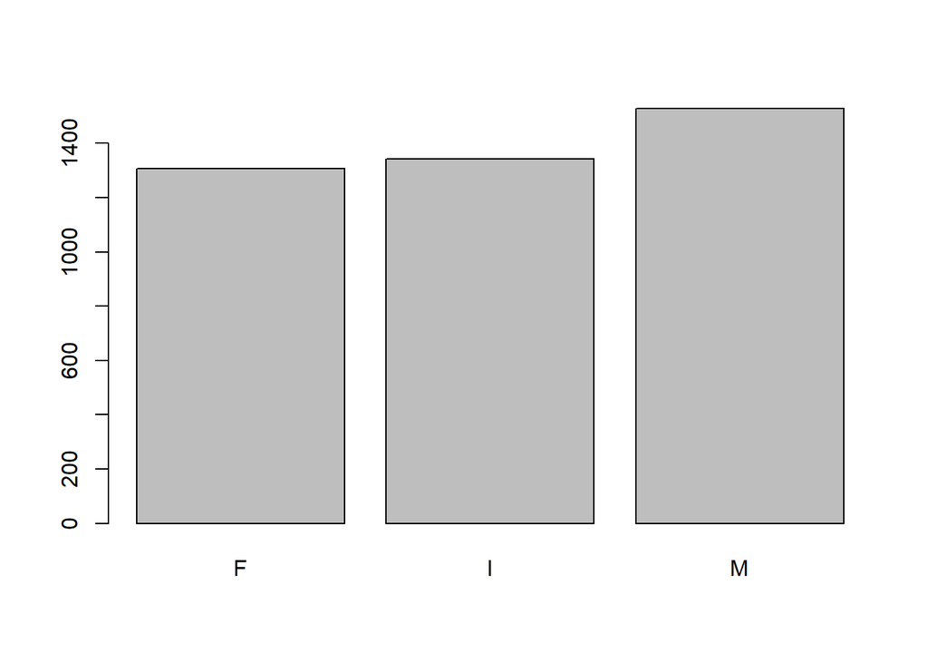

```r
plot(abalone$sex)
```

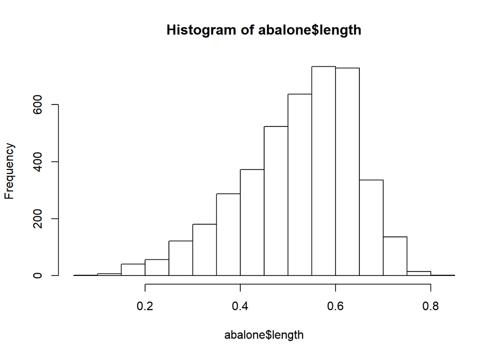

```r
hist(abalone$length)
```

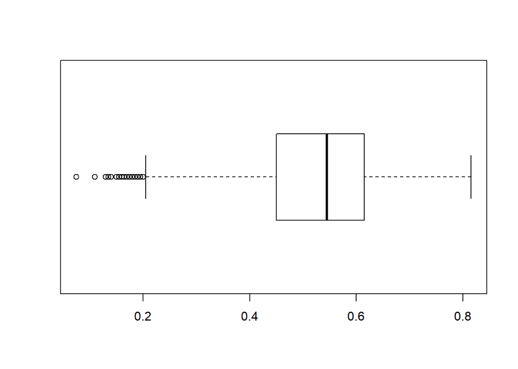

```r
boxplot(abalone$length, horizontal = TRUE)
```

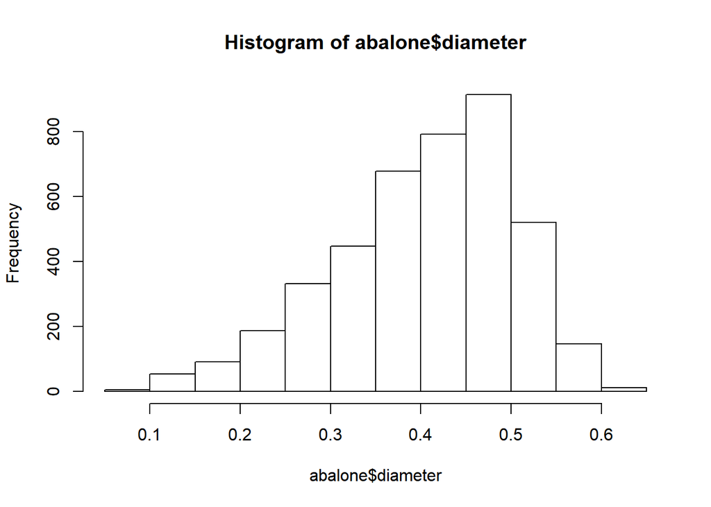

```r
hist(abalone$diameter)
```

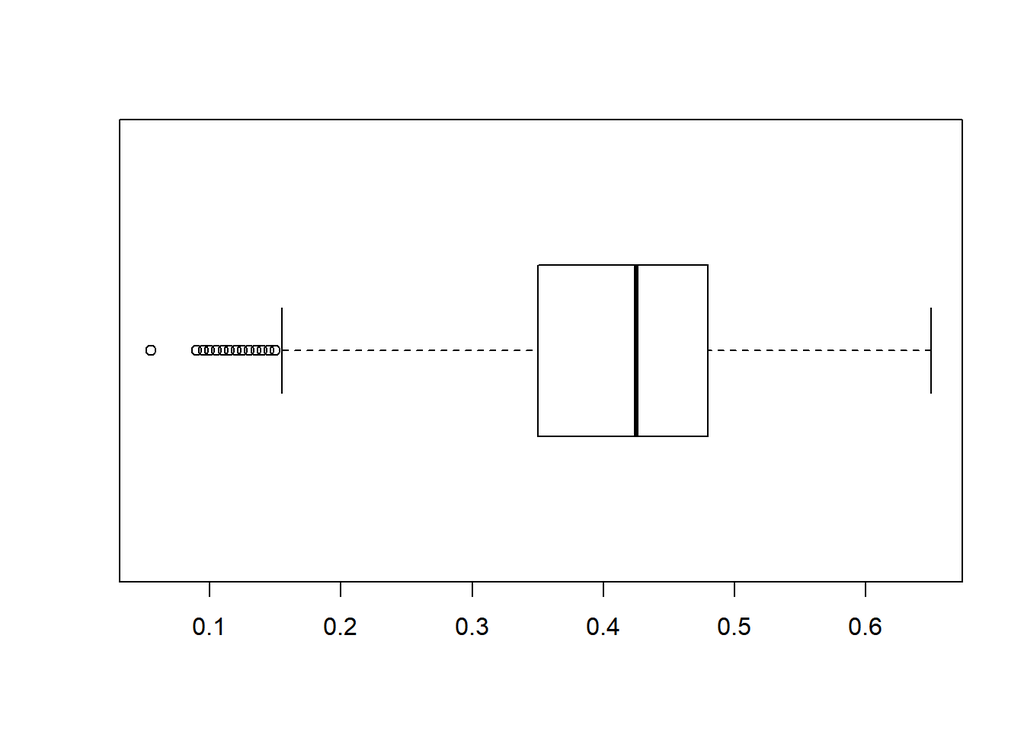

```r
boxplot(abalone$diameter, horizontal = TRUE)
```

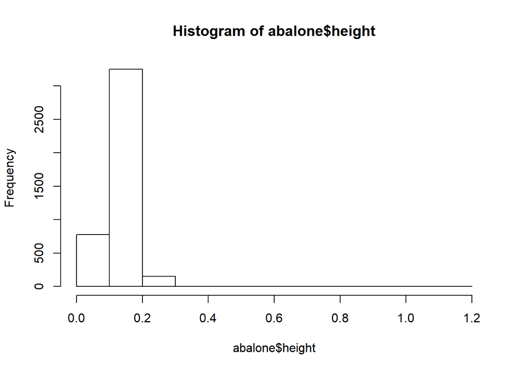

```r
hist(abalone$height)
```

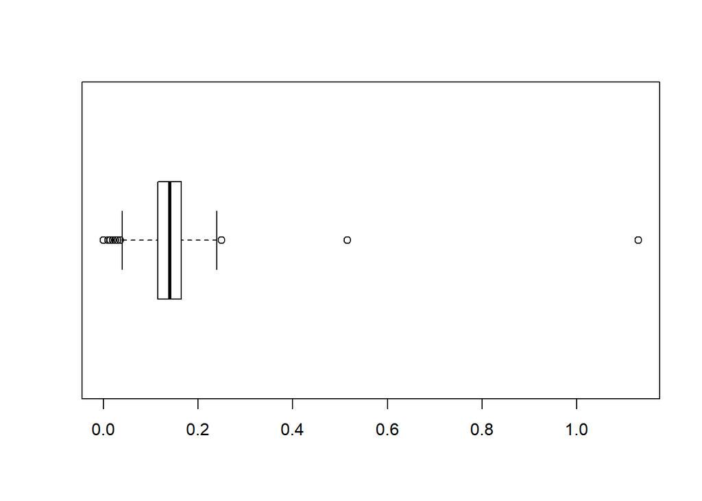

```r
boxplot(abalone$height, horizontal = TRUE)
```

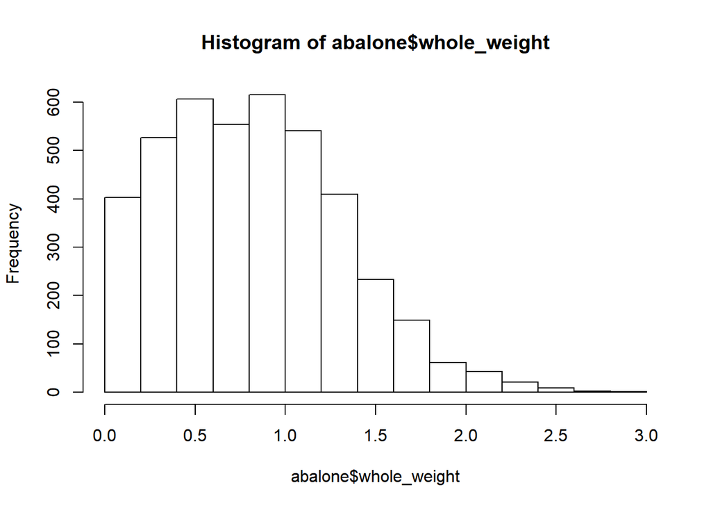

```r
hist(abalone$whole_weight)
```

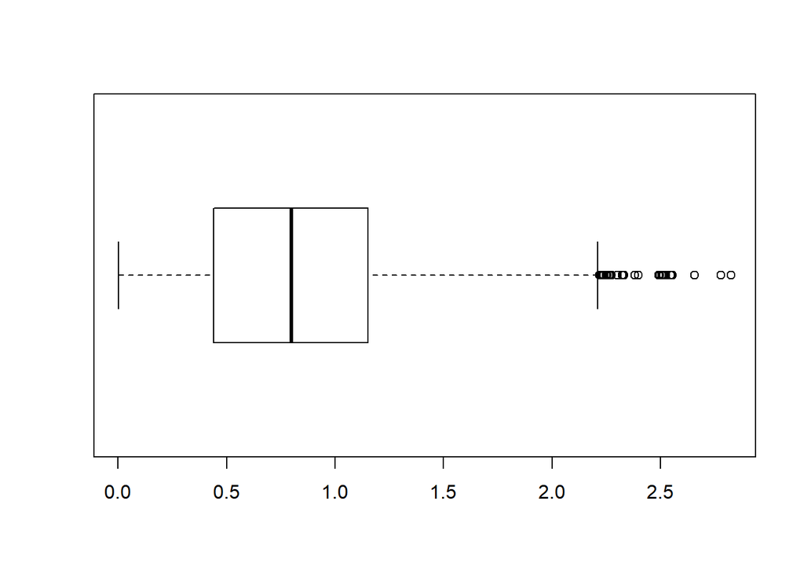

```r
boxplot(abalone$whole_weight, horizontal = TRUE)
```

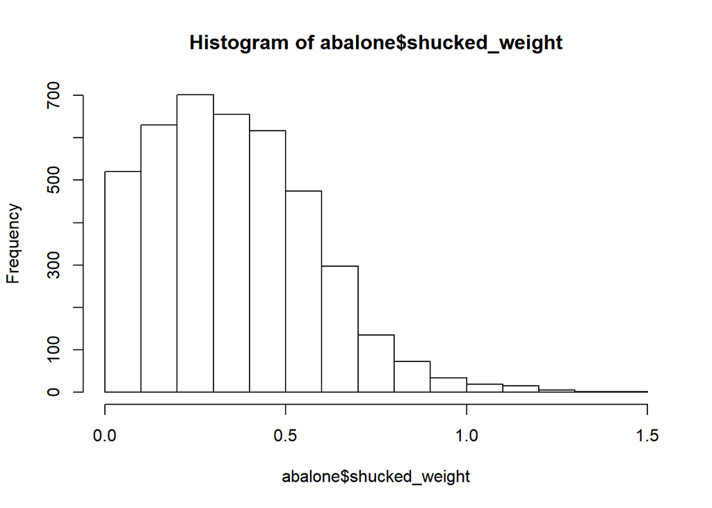

```r
hist(abalone$shucked_weight)
```

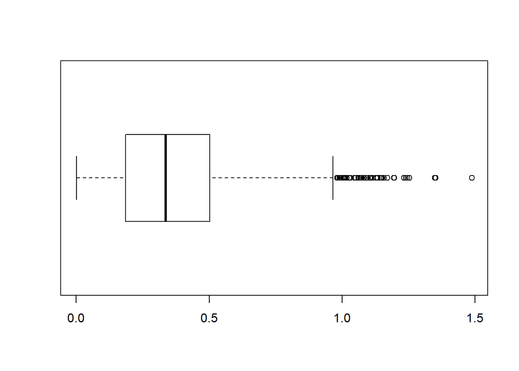

```r
boxplot(abalone$shucked_weight, horizontal = TRUE)
```

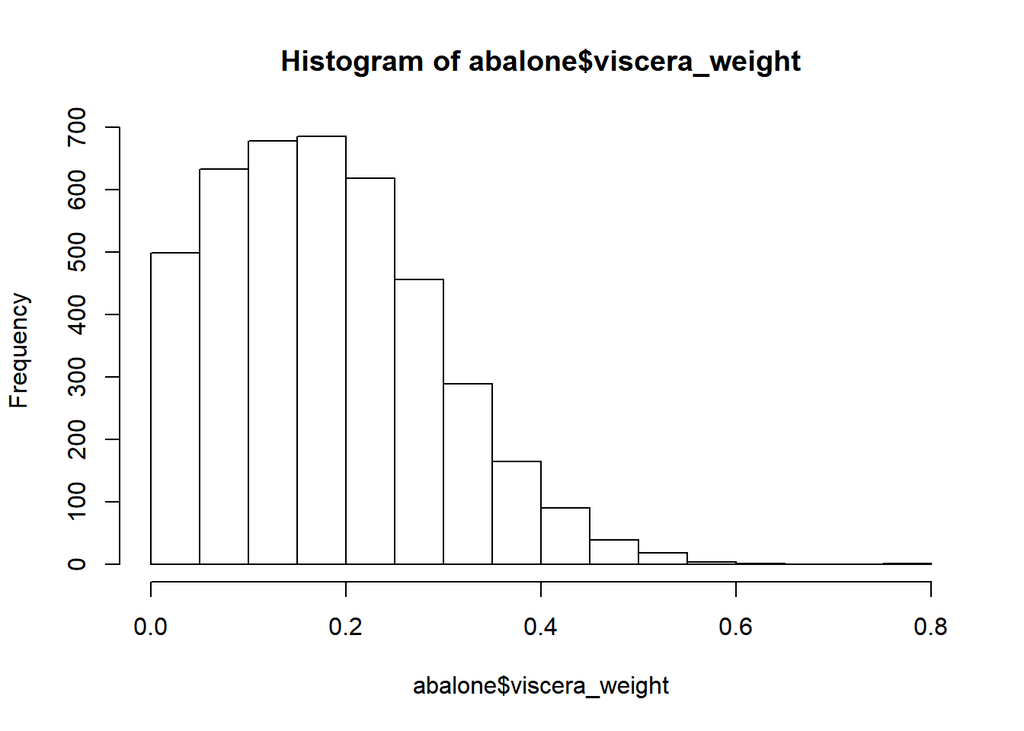

```r
hist(abalone$viscera_weight)
```

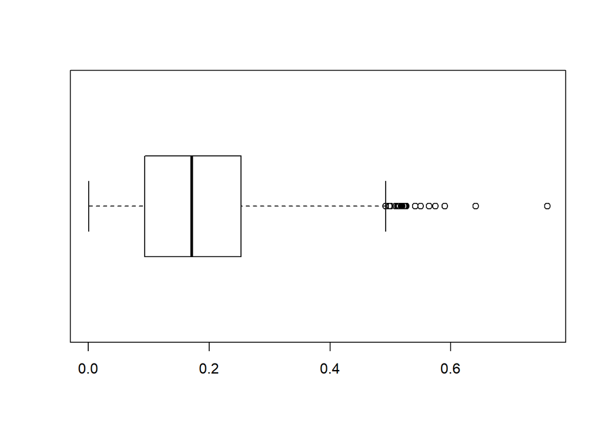

```r
boxplot(abalone$viscera_weight, horizontal = TRUE)
```

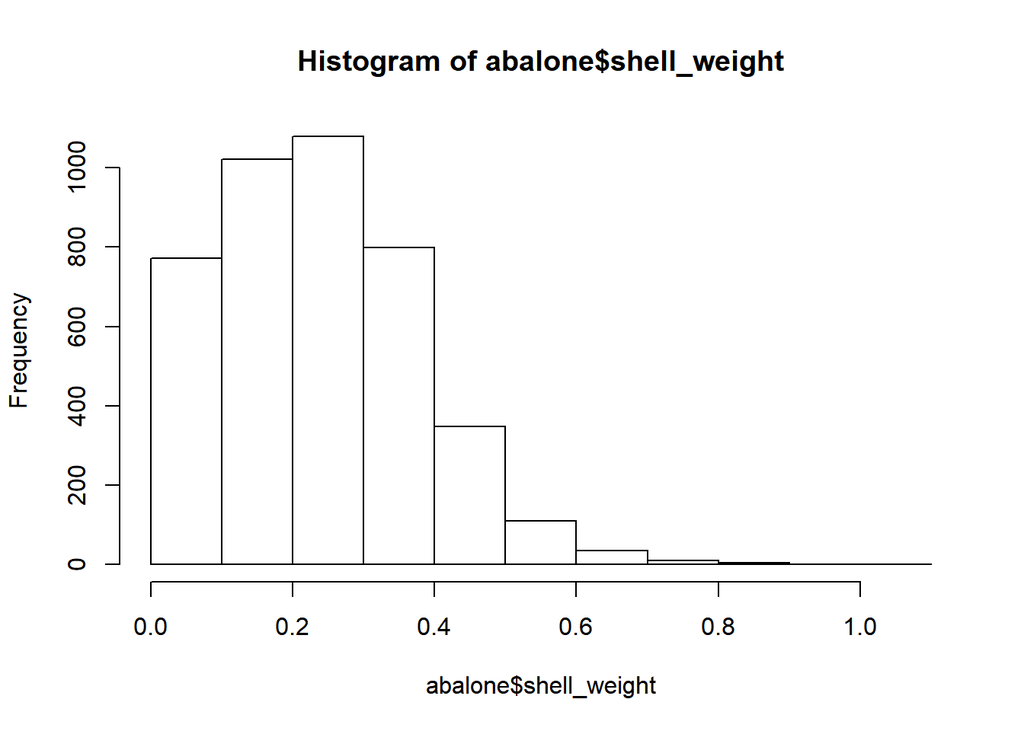

```r
hist(abalone$shell_weight)
```

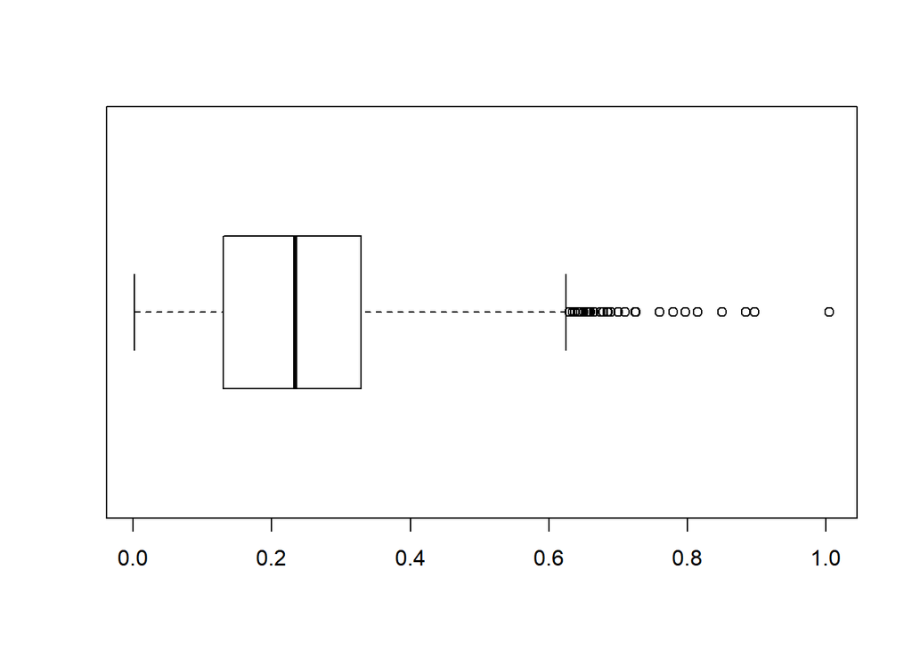

```r
boxplot(abalone$shell_weight, horizontal = TRUE)
```

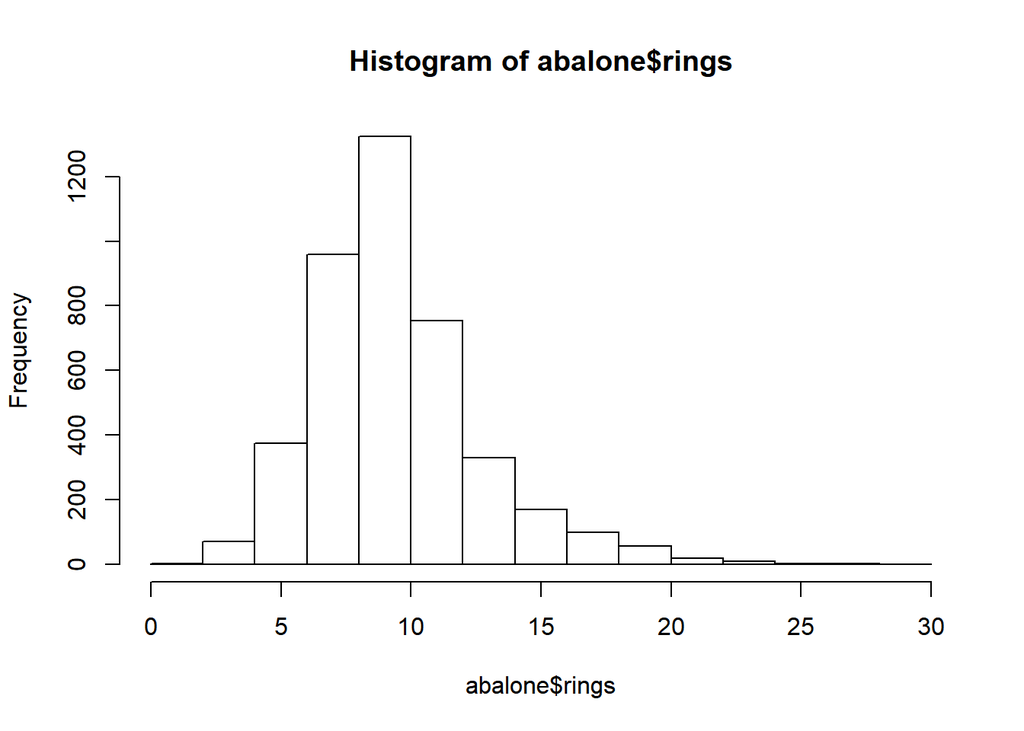

```r
hist(abalone$rings)
```

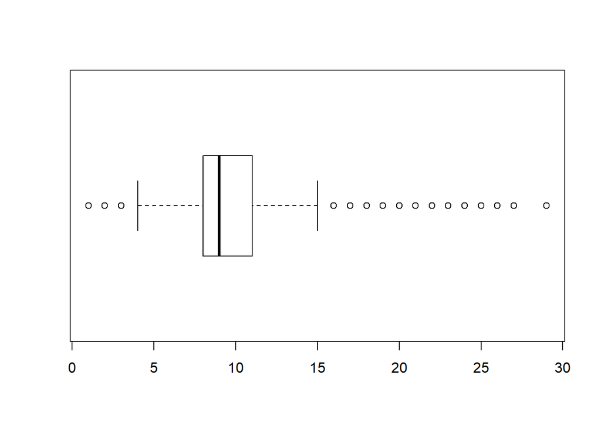

```r
boxplot(abalone$rings, horizontal = TRUE)
```

### Pittsburgh Bridges Data Set

```r
bridges <- read.csv("http://archive.ics.uci.edu/ml/machine-learning-databases/bridges/bridges.data.version1")
```

```r
head(bridges)
```

```
##   E1 M X3 X1818  HIGHWAY   X. X2 N THROUGH WOOD  SHORT S WOOD.1
## 1 E2 A 25  1819  HIGHWAY 1037  2 N THROUGH WOOD  SHORT S   WOOD
## 2 E3 A 39  1829 AQUEDUCT    ?  1 N THROUGH WOOD      ? S   WOOD
## 3 E5 A 29  1837  HIGHWAY 1000  2 N THROUGH WOOD  SHORT S   WOOD
## 4 E6 M 23  1838  HIGHWAY    ?  2 N THROUGH WOOD      ? S   WOOD
## 5 E7 A 27  1840  HIGHWAY  990  2 N THROUGH WOOD MEDIUM S   WOOD
## 6 E8 A 28  1844 AQUEDUCT 1000  1 N THROUGH IRON  SHORT S SUSPEN
```

```r
tail(bridges)
```

```
##       E1 M X3 X1818 HIGHWAY   X. X2 N THROUGH  WOOD  SHORT S WOOD.1
## 102  E85 M  9  1962 HIGHWAY 2213  4 G    DECK STEEL   LONG F CONT-T
## 103  E84 A 24  1969 HIGHWAY  870  6 G THROUGH STEEL MEDIUM F   ARCH
## 104  E91 O 44  1975 HIGHWAY 3756  6 G THROUGH STEEL   LONG F   ARCH
## 105  E90 M  7  1978 HIGHWAY  950  6 G THROUGH STEEL   LONG F   ARCH
## 106 E100 O 43  1982 HIGHWAY    ?  ? G       ?     ?      ? F      ?
## 107 E109 A 28  1986 HIGHWAY    ?  ? G       ?     ?      ? F      ?
```

```r
str(bridges)
```

```
## 'data.frame':    107 obs. of  13 variables:
##  $ E1     : Factor w/ 107 levels "E10","E100","E101",..: 20 31 53 64 75 86 97 1 11 12 ...
##  $ M      : Factor w/ 4 levels "A","M","O","Y": 1 1 1 2 1 1 2 1 1 1 ...
##  $ X3     : Factor w/ 55 levels "?","1","10","11",..: 19 35 23 17 21 22 24 35 23 35 ...
##  $ X1818  : int  1819 1829 1837 1838 1840 1844 1846 1848 1851 1853 ...
##  $ HIGHWAY: Factor w/ 4 levels "AQUEDUCT","HIGHWAY",..: 2 1 2 2 2 1 2 1 2 3 ...
##  $ X.     : Factor w/ 65 levels "?","1000","1030",..: 5 1 2 1 65 2 24 1 2 1 ...
##  $ X2     : Factor w/ 5 levels "?","1","2","4",..: 3 2 3 3 3 2 3 2 3 3 ...
##  $ N      : Factor w/ 3 levels "?","G","N": 3 3 3 3 3 3 3 3 3 3 ...
##  $ THROUGH: Factor w/ 3 levels "?","DECK","THROUGH": 3 3 3 3 3 3 3 2 3 2 ...
##  $ WOOD   : Factor w/ 4 levels "?","IRON","STEEL",..: 4 4 4 4 4 2 2 4 4 4 ...
##  $ SHORT  : Factor w/ 4 levels "?","LONG","MEDIUM",..: 4 1 4 1 3 4 4 1 3 1 ...
##  $ S      : Factor w/ 4 levels "?","F","S","S-F": 3 3 3 3 3 3 3 3 3 3 ...
##  $ WOOD.1 : Factor w/ 8 levels "?","ARCH","CANTILEV",..: 8 8 8 8 8 7 7 8 8 8 ...
```

```r
# download a copy of the data file
origin <- 'http://archive.ics.uci.edu/ml/machine-learning-databases/bridges/bridges.data.version1'
destination <- 'Pittsburgh_bridges.data'
download.file(origin, destination)
```

### Reading the Data

```r
# vector of column names
bridges_col_names <- c(
  "identity",
  "river",
  "location",
  "erected",
  "purpose",
  "length",
  "lanes",
  "clear-g",
  "t-or-d",
  "material",
  "span",
  "rel-l",
  "type"
)

# vector of column types
bridges_col_types <- c(
  'character',
  'factor',
  'numeric',
  'numeric',
  'factor',
  'numeric',
  'factor',
  'factor',
  'factor',
  'factor',
  'factor',
  'factor',
  'factor'
)

# reading the data with 'read.table()'
bridges <- read.table(
   'Pittsburgh_bridges.data',
    col.names = bridges_col_names,
    colClasses = bridges_col_types,
    sep = ",",
   na.strings = "?"

)
```

```r
# reading the data with 'read.csv()'
bridges <- read.csv(
  'Pittsburgh_bridges.data',
  col.names = bridges_col_names,
  colClasses = bridges_col_types,
  sep = ",",
  na.strings = "?",
  header = FALSE
)
```

### Basic Inspection

Use functions to start examining the `bridges` data frame:

```r
str(bridges)
```

```
## 'data.frame':    108 obs. of  13 variables:
##  $ identity: chr  "E1" "E2" "E3" "E5" ...
##  $ river   : Factor w/ 4 levels "A","M","O","Y": 2 1 1 1 2 1 1 2 1 1 ...
##  $ location: num  3 25 39 29 23 27 28 3 39 29 ...
##  $ erected : num  1818 1819 1829 1837 1838 ...
##  $ purpose : Factor w/ 4 levels "AQUEDUCT","HIGHWAY",..: 2 2 1 2 2 2 1 2 1 2 ...
##  $ length  : num  NA 1037 NA 1000 NA ...
##  $ lanes   : Factor w/ 4 levels "1","2","4","6": 2 2 1 2 2 2 1 2 1 2 ...
##  $ clear.g : Factor w/ 2 levels "G","N": 2 2 2 2 2 2 2 2 2 2 ...
##  $ t.or.d  : Factor w/ 2 levels "DECK","THROUGH": 2 2 2 2 2 2 2 2 1 2 ...
##  $ material: Factor w/ 3 levels "IRON","STEEL",..: 3 3 3 3 3 3 1 1 3 3 ...
##  $ span    : Factor w/ 3 levels "LONG","MEDIUM",..: 3 3 NA 3 NA 2 3 3 NA 2 ...
##  $ rel.l   : Factor w/ 3 levels "F","S","S-F": 2 2 2 2 2 2 2 2 2 2 ...
##  $ type    : Factor w/ 7 levels "ARCH","CANTILEV",..: 7 7 7 7 7 7 6 6 7 7 ...
```

```r
summary(bridges)
```

```
##    identity         river     location        erected         purpose
##  Length:108         A:49   Min.   : 1.00   Min.   :1818   AQUEDUCT: 4
##  Class :character   M:41   1st Qu.:15.50   1st Qu.:1884   HIGHWAY :71
##  Mode  :character   O:15   Median :27.00   Median :1903   RR      :32
##                     Y: 3   Mean   :25.98   Mean   :1905   WALK    : 1
##                            3rd Qu.:37.50   3rd Qu.:1928
##                            Max.   :52.00   Max.   :1986
##                            NA's   :1
##      length      lanes    clear.g       t.or.d    material      span
##  Min.   : 804   1   : 4   G   :80   DECK   :15   IRON :11   LONG  :30
##  1st Qu.:1000   2   :61   N   :26   THROUGH:87   STEEL:79   MEDIUM:53
##  Median :1300   4   :23   NA's: 2   NA's   : 6   WOOD :16   SHORT : 9
##  Mean   :1567   6   : 4                          NA's : 2   NA's  :16
##  3rd Qu.:2000   NA's:16
##  Max.   :4558
##  NA's   :27
##   rel.l          type
##  F   :58   SIMPLE-T:44
##  S   :30   WOOD    :16
##  S-F :15   ARCH    :13
##  NA's: 5   CANTILEV:11
##            SUSPEN  :11
##            (Other) :11
##            NA's    : 2
```

```r
head(bridges)
```

```
##   identity river location erected  purpose length lanes clear.g  t.or.d
## 1       E1     M        3    1818  HIGHWAY     NA     2       N THROUGH
## 2       E2     A       25    1819  HIGHWAY   1037     2       N THROUGH
## 3       E3     A       39    1829 AQUEDUCT     NA     1       N THROUGH
## 4       E5     A       29    1837  HIGHWAY   1000     2       N THROUGH
## 5       E6     M       23    1838  HIGHWAY     NA     2       N THROUGH
## 6       E7     A       27    1840  HIGHWAY    990     2       N THROUGH
##   material   span rel.l type
## 1     WOOD  SHORT     S WOOD
## 2     WOOD  SHORT     S WOOD
## 3     WOOD   <NA>     S WOOD
## 4     WOOD  SHORT     S WOOD
## 5     WOOD   <NA>     S WOOD
## 6     WOOD MEDIUM     S WOOD
```

```r
tail(bridges)
```

```
##     identity river location erected purpose length lanes clear.g  t.or.d
## 103      E85     M        9    1962 HIGHWAY   2213     4       G    DECK
## 104      E84     A       24    1969 HIGHWAY    870     6       G THROUGH
## 105      E91     O       44    1975 HIGHWAY   3756     6       G THROUGH
## 106      E90     M        7    1978 HIGHWAY    950     6       G THROUGH
## 107     E100     O       43    1982 HIGHWAY     NA  <NA>       G    <NA>
## 108     E109     A       28    1986 HIGHWAY     NA  <NA>       G    <NA>
##     material   span rel.l   type
## 103    STEEL   LONG     F CONT-T
## 104    STEEL MEDIUM     F   ARCH
## 105    STEEL   LONG     F   ARCH
## 106    STEEL   LONG     F   ARCH
## 107     <NA>   <NA>     F   <NA>
## 108     <NA>   <NA>     F   <NA>
```

```r
dim(bridges)
```

```
## [1] 108  13
```

```r
names(bridges)
```

```
##  [1] "identity" "river"    "location" "erected"  "purpose"  "length"
##  [7] "lanes"    "clear.g"  "t.or.d"   "material" "span"     "rel.l"
## [13] "type"
```

```r
colnames(bridges)
```

```
##  [1] "identity" "river"    "location" "erected"  "purpose"  "length"
##  [7] "lanes"    "clear.g"  "t.or.d"   "material" "span"     "rel.l"
## [13] "type"
```

```r
nrow(bridges)
```

```
## [1] 108
```

```r
ncol(bridges)
```

```
## [1] 13
```

Write R code to find: - Year of the oldest bridge

```r
min(bridges$erected)
```

```
## [1] 1818
```

- Year of the most recent erected bridge

```r
max(bridges$erected)
```

```
## [1] 1986
```

- Frequency of bridges by purpose

```r
table(bridges$purpose)
```

```
##
## AQUEDUCT  HIGHWAY       RR     WALK
##        4       71       32        1
```

- Frequency of materials

```r
table(bridges$material)
```

```
##
##  IRON STEEL  WOOD
##    11    79    16
```

- Average length of the bridges

```r
mean(bridges$length, na.rm = TRUE)
```

```
## [1] 1567.469
```

Plot a timeline: year -vs- length

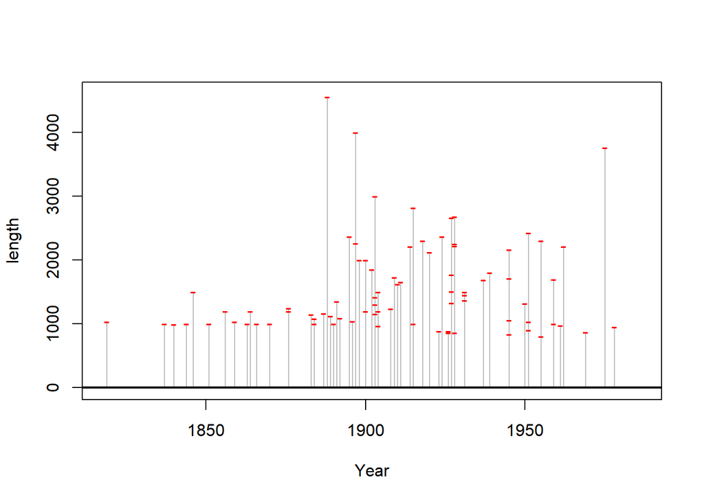

```r
with(bridges, {
    plot(erected, length, type = "h",
         xlab = "Year", col="grey", ylim=c(0, 4600))
    points(erected, length, pch = "-", col = "red")
  })
  abline(h=0, lwd=2)
```